# Эксперимент 1

Код с анализом данных из оригинального эксперимента, на который я опиралась, можно найти [здесь](https://osf.io/6zah8/files/osfstorage).

```r
library(readxl)
library(brms)
library(tidyverse)
options(mc.cores = 4)
set.seed(1794)
```

Для порядкой регрессии нужно удостовериться, что модель будет считывать все переменные как категориальные.

```r
df_if_sentences <- read_excel("df_if_sentences.xlsx")
df_if_quant_sentences <- read_excel("df_if_quant_sentences.xlsx")

# преобразуем переменные в категориальные
convert_vars <- function(df, ordinal_var, factor_vars) {
  df[[ordinal_var]] <- factor(df[[ordinal_var]], ordered = TRUE)
  df <- df %>%
    mutate(across(all_of(factor_vars), as.factor))
  return(df)
}

df_if_sentences <- convert_vars(
  df_if_sentences,
  ordinal_var = "Rating",
  factor_vars = c("NPI", "Mood")
)

df_if_quant_sentences <- convert_vars(
  df_if_quant_sentences,
  ordinal_var = "Rating",
  factor_vars = c("NPI", "Structure")
)
```

```r
df_if_sentences$NPI <- relevel(df_if_sentences$NPI, ref = "yes")
df_if_quant_sentences$NPI <- relevel(df_if_quant_sentences$NPI, ref = "yes")
df_if_quant_sentences$Structure <- relevel(df_if_quant_sentences$Structure, ref = "Universal Q")
```

```r
df_if_sentences$NPI_cont <- as.factor(df_if_sentences$NPI)
df_if_sentences$Mood_cont <- as.factor(df_if_sentences$Mood)
df_if_sentences$Structure_cont <- as.factor(df_if_sentences$Structure)

df_if_quant_sentences$NPI_cont <- as.factor(df_if_quant_sentences$NPI)
df_if_quant_sentences$Mood_cont <- as.factor(df_if_quant_sentences$Mood)
df_if_quant_sentences$Structure_cont <- as.factor(df_if_quant_sentences$Structure)

contrasts(df_if_sentences$NPI_cont) <- c(-.5,.5)
contrasts(df_if_sentences$Mood_cont) <- c(-.5,.5)
contrasts(df_if_quant_sentences$NPI_cont) <- c(-.5,.5)
contrasts(df_if_quant_sentences$Structure_cont) <- c(-.5,.5)
```

Формулы для 4 моделей

```r
# с контрастами
if_formula_cont <- Rating ~ NPI_cont * Mood_cont +
  (1 + NPI_cont * Mood_cont | Model) +
  (1 + NPI_cont * Mood_cont | Item)

if_formula_dum <- Rating ~ NPI * Mood +
  (1 + NPI * Mood | Model) +
  (1 + NPI * Mood | Item)

# с контрастами
quant_formula_cont <- Rating ~ NPI_cont * Structure_cont +
  (1 + NPI_cont * Structure_cont | Model) +
  (1 + NPI_cont * Structure_cont | Item)

quant_formula_dum <- Rating ~ NPI * Structure +
  (1 + NPI * Structure | Model) +
  (1 + NPI * Structure | Item)
```

```r
priors <- c(
  set_prior("normal(0, 0.9)", class = "b"),  # для коэф. регрессии
  set_prior("exponential(0.68)", class = "sd", group = "Model"),  # случайный эффект моделей
  set_prior("exponential(0.61)", class = "sd", group = "Item")  # случайный эффект айтемов
)
```

```r
# модель 1 для датасета, где мы противопоставляем
# индикативные кондиционалы с контрафктическими и учитываем контрасты
model_NPI_if <- brm(
  formula = if_formula_cont,
  data = df_if_sentences,
  family = cumulative("probit"),
  chains = 4,
  iter = 8000,
  prior = priors,
  seed = 1794,
  control = list(adapt_delta = 0.99, max_treedepth = 12)
)
```

```r
summary(model_NPI_if)
```

```
 Family: cumulative
  Links: mu = probit; disc = identity
Formula: Rating ~ NPI_cont * Mood_cont + (1 + NPI_cont * Mood_cont | Model) + (1 + NPI_cont * Mood_cont | Item)
   Data: df_if_sentences (Number of observations: 768)
  Draws: 4 chains, each with iter = 8000; warmup = 4000; thin = 1;
         total post-warmup draws = 16000

Multilevel Hyperparameters:
~Item (Number of levels: 24)
                                     Estimate Est.Error l-95% CI u-95% CI Rhat Bulk_ESS Tail_ESS
sd(Intercept)                            0.24      0.07     0.11     0.38 1.00     5902     6361
sd(NPI_cont1)                            0.26      0.13     0.03     0.53 1.00     5402     5082
sd(Mood_cont1)                           0.80      0.16     0.53     1.16 1.00     7937     9919
sd(NPI_cont1:Mood_cont1)                 0.33      0.21     0.02     0.78 1.00     7888     7476
cor(Intercept,NPI_cont1)                 0.37      0.35    -0.43     0.90 1.00    11211    11016
cor(Intercept,Mood_cont1)                0.09      0.26    -0.42     0.59 1.00     4959     7427
cor(NPI_cont1,Mood_cont1)                0.25      0.33    -0.45     0.81 1.00     2058     3332
cor(Intercept,NPI_cont1:Mood_cont1)      0.17      0.40    -0.65     0.84 1.00    15881    10915
cor(NPI_cont1,NPI_cont1:Mood_cont1)      0.28      0.41    -0.63     0.90 1.00    10071    11269
cor(Mood_cont1,NPI_cont1:Mood_cont1)     0.34      0.38    -0.54     0.89 1.00    15098    11892

~Model (Number of levels: 8)
                                     Estimate Est.Error l-95% CI u-95% CI Rhat Bulk_ESS Tail_ESS
sd(Intercept)                            0.92      0.27     0.54     1.58 1.00     6485     9409
sd(NPI_cont1)                            1.16      0.37     0.64     2.07 1.00     6535     9573
sd(Mood_cont1)                           1.83      0.48     1.12     2.96 1.00     7241     9629
sd(NPI_cont1:Mood_cont1)                 1.57      0.45     0.91     2.66 1.00     8710    11024
cor(Intercept,NPI_cont1)                -0.25      0.29    -0.74     0.35 1.00     7968     9325
cor(Intercept,Mood_cont1)                0.08      0.28    -0.47     0.61 1.00     7558     9358
cor(NPI_cont1,Mood_cont1)                0.36      0.26    -0.23     0.78 1.00     7388     9752
cor(Intercept,NPI_cont1:Mood_cont1)      0.42      0.26    -0.16     0.82 1.00     9338    10556
cor(NPI_cont1,NPI_cont1:Mood_cont1)     -0.03      0.29    -0.58     0.54 1.00     9567    10915
cor(Mood_cont1,NPI_cont1:Mood_cont1)    -0.50      0.24    -0.86     0.05 1.00    12295    13042

Regression Coefficients:
                     Estimate Est.Error l-95% CI u-95% CI Rhat Bulk_ESS Tail_ESS
Intercept[1]            -3.65      0.37    -4.38    -2.91 1.00     3722     7136
Intercept[2]            -2.61      0.34    -3.27    -1.93 1.00     3469     6778
Intercept[3]            -1.70      0.33    -2.35    -1.04 1.00     3301     6329
Intercept[4]            -1.00      0.33    -1.64    -0.35 1.00     3314     6062
Intercept[5]             0.30      0.32    -0.34     0.96 1.00     3288     6463
Intercept[6]             1.83      0.33     1.19     2.50 1.00     3464     6418
NPI_cont1                1.30      0.39     0.46     2.01 1.00     5733     8504
Mood_cont1               0.41      0.54    -0.69     1.43 1.00     6586     9415
NPI_cont1:Mood_cont1    -0.61      0.48    -1.53     0.36 1.00     7737    10324

Further Distributional Parameters:
     Estimate Est.Error l-95% CI u-95% CI Rhat Bulk_ESS Tail_ESS
disc     1.00      0.00     1.00     1.00   NA       NA       NA

Draws were sampled using sampling(NUTS). For each parameter, Bulk_ESS
and Tail_ESS are effective sample size measures, and Rhat is the potential
scale reduction factor on split chains (at convergence, Rhat = 1).
```

```r
post_model.1 <- posterior_samples(model_NPI_if)
```

При n > 0, мы смотрим, насколько вероятно, что коэффициент будет положительным, и наоборот.

```r
mean(post_model.1$'b_NPI_cont1' > 0)
```

```
[1] 0.997125
```

```r
mean(post_model.1$'b_Mood_cont1' > 0)
```

```
[1] 0.783375
```

```r
mean(post_model.1$'b_NPI_cont1:Mood_cont1' < 0)
```

```
[1] 0.9008125
```

b_NPI_cont1 статистически значим => наличие NPI ухудшает оценку всех предложений. Mood_cont1 не имеет статистической значимости (индикативы и контрфактивы вне зависимости от наличия NPI оцениваются одинаково). NPI_cont1:Mood_cont1 — эффект наличия NPI влияет больше на идикативы, чем на контрфактивы. Однако стоит отметить, что этот эффект не особо устойчив.

```r
# модель 2 для того же датасета, что и в 1,
# только без контрастов
model_NPI_if_dum <- brm(
  formula = if_formula_dum,
  data = df_if_sentences,
  family = cumulative("probit"),
  chains = 4,
  iter = 8000,
  prior = priors,
  seed = 1794,
  control = list(adapt_delta = 0.99, max_treedepth = 12)
)
```

```r
summary(model_NPI_if_dum)
```

```
 Family: cumulative
  Links: mu = probit; disc = identity
Formula: Rating ~ NPI * Mood + (1 + NPI * Mood | Model) + (1 + NPI * Mood | Item)
   Data: df_if_sentences (Number of observations: 768)
  Draws: 4 chains, each with iter = 8000; warmup = 4000; thin = 1;
         total post-warmup draws = 16000

Multilevel Hyperparameters:
~Item (Number of levels: 24)
                                           Estimate Est.Error l-95% CI u-95% CI Rhat Bulk_ESS Tail_ESS
sd(Intercept)                                  0.37      0.10     0.18     0.59 1.00     5485     6196
sd(NPIno)                                      0.18      0.12     0.01     0.46 1.00     3773     5795
sd(MoodSubjunctive)                            0.61      0.15     0.33     0.94 1.00     5463     6932
sd(NPIno:MoodSubjunctive)                      0.51      0.21     0.10     0.94 1.00     3284     3229
cor(Intercept,NPIno)                           0.10      0.41    -0.69     0.83 1.00    12841    10950
cor(Intercept,MoodSubjunctive)                -0.73      0.17    -0.95    -0.28 1.00     5111     7692
cor(NPIno,MoodSubjunctive)                    -0.11      0.41    -0.82     0.70 1.00     3935     7318
cor(Intercept,NPIno:MoodSubjunctive)          -0.26      0.32    -0.82     0.39 1.00     7390     8801
cor(NPIno,NPIno:MoodSubjunctive)              -0.03      0.42    -0.79     0.78 1.00     3087     5910
cor(MoodSubjunctive,NPIno:MoodSubjunctive)     0.30      0.32    -0.35     0.85 1.00     8240    10847

~Model (Number of levels: 8)
                                           Estimate Est.Error l-95% CI u-95% CI Rhat Bulk_ESS Tail_ESS
sd(Intercept)                                  1.57      0.35     1.03     2.40 1.00     4660     7257
sd(NPIno)                                      1.22      0.34     0.72     2.06 1.00     5170     7960
sd(MoodSubjunctive)                            2.18      0.56     1.37     3.54 1.00     6534     9911
sd(NPIno:MoodSubjunctive)                      1.44      0.42     0.83     2.46 1.00     7085     9453
cor(Intercept,NPIno)                          -0.79      0.18    -0.97    -0.29 1.00     5020     6539
cor(Intercept,MoodSubjunctive)                -0.52      0.23    -0.85     0.03 1.00     5566     8399
cor(NPIno,MoodSubjunctive)                     0.46      0.25    -0.12     0.83 1.00     6731     9673
cor(Intercept,NPIno:MoodSubjunctive)           0.51      0.23    -0.03     0.86 1.00     8524     9552
cor(NPIno,NPIno:MoodSubjunctive)              -0.29      0.28    -0.75     0.32 1.00     9477    10969
cor(MoodSubjunctive,NPIno:MoodSubjunctive)    -0.50      0.25    -0.87     0.09 1.00    11374    12071

Regression Coefficients:
                      Estimate Est.Error l-95% CI u-95% CI Rhat Bulk_ESS Tail_ESS
Intercept[1]             -2.59      0.53    -3.67    -1.56 1.00     3351     5939
Intercept[2]             -1.57      0.51    -2.59    -0.59 1.00     3175     5287
Intercept[3]             -0.68      0.50    -1.68     0.29 1.00     3129     5645
Intercept[4]              0.02      0.50    -0.98     0.99 1.00     3125     5394
Intercept[5]              1.32      0.50     0.32     2.29 1.00     3138     5375
Intercept[6]              2.86      0.51     1.85     3.86 1.00     3200     5546
NPIno                     1.56      0.41     0.67     2.31 1.00     4029     6193
MoodSubjunctive           0.52      0.59    -0.69     1.61 1.00     5687     8464
NPIno:MoodSubjunctive    -0.49      0.45    -1.35     0.42 1.00     6721     9750

Further Distributional Parameters:
     Estimate Est.Error l-95% CI u-95% CI Rhat Bulk_ESS Tail_ESS
disc     1.00      0.00     1.00     1.00   NA       NA       NA

Draws were sampled using sampling(NUTS). For each parameter, Bulk_ESS
and Tail_ESS are effective sample size measures, and Rhat is the potential
scale reduction factor on split chains (at convergence, Rhat = 1).
```

```r
post_model.2 <- posterior_samples(model_NPI_if_dum)
```

```r
mean(post_model.2$'b_NPIno' > 0)
```

```
[1] 0.998625
```

```r
mean(post_model.2$'b_MoodSubjunctive' > 0)
```

```
[1] 0.814375
```

```r
mean(post_model.2$'b_NPIno:MoodSubjunctive' < 0)
```

```
[1] 0.8654375
```

NPIno => Индикативные предложения с NPI оцениваются хуже, чем те, что без NPI. MoodSubjunctive => эффект незначим (при наличии NPI индикативы и контрфактивы оценивацются одинаково). NPIno:MoodSubjunctive => эффект незначим (наличие или отсутствие NPI не влияет на разницу в оценках между индикативами и контрфактивами).

```r
hypotheses_if<-c(
  # существует ли разница между индикативными и контрафакт. предложениями без NPI
  "IND.vs.SUBJV.withoutNPI" = "MoodSubjunctive+NPIno:MoodSubjunctive*1=0",

  # существует ли разница между предложениями в сослагательном наклонении с NPI и без
  "NPI.vs.noNPI.inSUBJUNCTIVES" = "NPIno+NPIno:MoodSubjunctive*1=0"
)

hyp_post<-hypothesis(model_NPI_if_dum, hypotheses_if)
hyp_post
```

```
Hypothesis Tests for class b:
```

| Hypothesis | Estimate | Est.Error | CI.Lower | CI.Upper | Evid.Ratio | Post.Prob | Star |
| --- | --- | --- | --- | --- | --- | --- | --- |
| IND.vs.SUBJV.withoutNPI | 0.03 | 0.62 | -1.28 | 1.21 | NA | NA |  |
| NPI.vs.noNPI.inSU...IVES | 1.07 | 0.56 | -0.09 | 2.15 | NA | NA |  |

```
---
'CI': 90%-CI for one-sided and 95%-CI for two-sided hypotheses.
'*': For one-sided hypotheses, the posterior probability exceeds 95%;
for two-sided hypotheses, the value tested against lies outside the 95%-CI.
Posterior probabilities of point hypotheses assume equal prior probabilities.
```

Без NPI нет разницы между индикативными и контрфактивными кондиционалами. Контрфактивы без NPI оцениваются лучше, чем с NPI, но эффект на грани значимости.

Графики апостериорных распределений

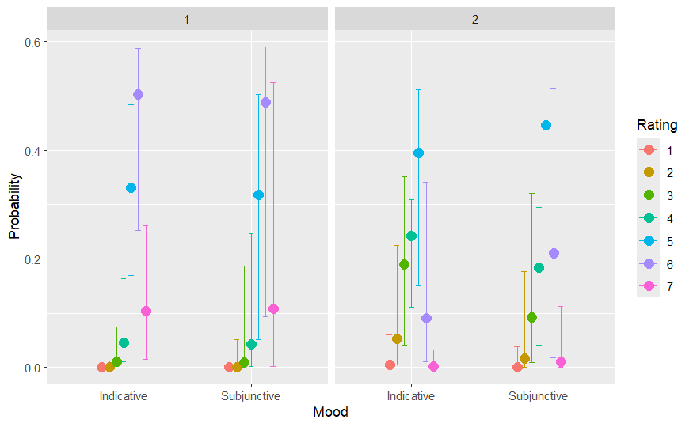

```r
conditions <- data.frame(NPI=c("no", "yes"))
post_plot<-conditional_effects(model_NPI_if_dum, effects = "Mood",
  conditions = conditions, categorical = TRUE, transform = NULL,
  resolution = 1000, points=TRUE, rug=TRUE, style="raster")
post_plot
```

```r
# модель 3 для датасета, где мы противопоставляем индикативные предложения
# с квантором всеобщности и без с учётом контрастов
model_NPI_quant <- brm(
  formula = quant_formula_cont,
  data = df_if_quant_sentences,
  family = cumulative("probit"),
  chains = 4,
  iter = 8000,
  prior = priors,
  seed = 1794,
  control = list(adapt_delta = 0.99, max_treedepth = 12)
)
```

```r
summary(model_NPI_quant)
```

```
 Family: cumulative
  Links: mu = probit; disc = identity
Formula: Rating ~ NPI_cont * Structure_cont + (1 + NPI_cont * Structure_cont | Model) + (1 + NPI_cont * Structure_cont | Item)
   Data: df_if_quant_sentences (Number of observations: 768)
  Draws: 4 chains, each with iter = 8000; warmup = 4000; thin = 1;
         total post-warmup draws = 16000

Multilevel Hyperparameters:
~Item (Number of levels: 24)
                                               Estimate Est.Error l-95% CI u-95% CI Rhat Bulk_ESS Tail_ESS
sd(Intercept)                                      0.42      0.08     0.28     0.60 1.00     5484     9920
sd(NPI_cont1)                                      0.21      0.12     0.01     0.47 1.00     5337     5980
sd(Structure_cont1)                                0.09      0.07     0.00     0.25 1.00    11002     7259
sd(NPI_cont1:Structure_cont1)                      0.24      0.18     0.01     0.65 1.00     8776     8330
cor(Intercept,NPI_cont1)                           0.29      0.36    -0.51     0.85 1.00    16940    10171
cor(Intercept,Structure_cont1)                     0.11      0.44    -0.76     0.85 1.00    26867     9904
cor(NPI_cont1,Structure_cont1)                     0.02      0.44    -0.79     0.82 1.00    21575    12295
cor(Intercept,NPI_cont1:Structure_cont1)          -0.15      0.42    -0.85     0.71 1.00    23615    11547
cor(NPI_cont1,NPI_cont1:Structure_cont1)          -0.17      0.44    -0.87     0.73 1.00    13972    12307
cor(Structure_cont1,NPI_cont1:Structure_cont1)    -0.01      0.44    -0.81     0.80 1.00    13369    13216

~Model (Number of levels: 8)
                                               Estimate Est.Error l-95% CI u-95% CI Rhat Bulk_ESS Tail_ESS
sd(Intercept)                                      0.91      0.22     0.59     1.45 1.00     5043     7748
sd(NPI_cont1)                                      1.15      0.39     0.62     2.09 1.00     5844     8554
sd(Structure_cont1)                                0.66      0.24     0.33     1.23 1.00     7144     9493
sd(NPI_cont1:Structure_cont1)                      2.58      0.60     1.69     4.01 1.00     6412     8942
cor(Intercept,NPI_cont1)                           0.04      0.27    -0.50     0.55 1.00     6166     8677
cor(Intercept,Structure_cont1)                     0.40      0.26    -0.18     0.81 1.00     9295    11023
cor(NPI_cont1,Structure_cont1)                    -0.37      0.29    -0.83     0.28 1.00     8674    10478
cor(Intercept,NPI_cont1:Structure_cont1)          -0.80      0.15    -0.97    -0.39 1.00     8677    11178
cor(NPI_cont1,NPI_cont1:Structure_cont1)          -0.31      0.25    -0.73     0.21 1.00    11722    11484
cor(Structure_cont1,NPI_cont1:Structure_cont1)    -0.15      0.27    -0.64     0.41 1.00    11755    11936

Regression Coefficients:
                          Estimate Est.Error l-95% CI u-95% CI Rhat Bulk_ESS Tail_ESS
Intercept[1]                 -3.05      0.30    -3.64    -2.46 1.00     3308     6033
Intercept[2]                 -2.11      0.28    -2.66    -1.55 1.00     3144     6335
Intercept[3]                 -1.25      0.28    -1.79    -0.70 1.00     3069     6197
Intercept[4]                 -0.25      0.27    -0.79     0.30 1.00     3045     6257
Intercept[5]                  0.69      0.28     0.15     1.24 1.00     3057     5906
Intercept[6]                  2.26      0.29     1.70     2.83 1.00     3154     6453
NPI_cont1                     1.71      0.40     0.83     2.40 1.00     4973     7129
Structure_cont1               0.05      0.24    -0.44     0.54 1.00     5916     8506
NPI_cont1:Structure_cont1     0.10      0.63    -1.14     1.35 1.00     5946     9036

Further Distributional Parameters:
     Estimate Est.Error l-95% CI u-95% CI Rhat Bulk_ESS Tail_ESS
disc     1.00      0.00     1.00     1.00   NA       NA       NA

Draws were sampled using sampling(NUTS). For each parameter, Bulk_ESS
and Tail_ESS are effective sample size measures, and Rhat is the potential
scale reduction factor on split chains (at convergence, Rhat = 1).
```

```r
post_model.3 <- posterior_samples(model_NPI_quant)
```

```r
mean(post_model.3$'b_NPI_cont1' > 0)
```

```
[1] 0.998875
```

```r
mean(post_model.3$'b_Structure_cont1' > 0)
```

```
[1] 0.5870625
```

```r
mean(post_model.3$'b_NPI_cont1:Structure_cont1' > 0)
```

```
[1] 0.562875
```

NPI_cont1 => наличие NPI ухудшает оценки для всех предложений. Structure_cont1 => нет разницы в оценках между предложениями с и без квантора всеобщности. NPI_cont1:Structure_cont1 => нет доказательства, что эффект NPI отличается для предложений с и без квантора всеобщности.

```r
# модель 4 для того же датасета, что и в 3,
# только без контрастов
model_NPI_quant_dum <- brm(
  formula = quant_formula_dum,
  data = df_if_quant_sentences,
  family = cumulative("probit"),
  chains = 4,
  iter = 8000,
  prior = priors,
  seed = 1794,
  control = list(adapt_delta = 0.99, max_treedepth = 12)
)
```